# Genetic Analysis Package

Jing Hua Zhao

University of Cambridge

Cambridge, UK

https://jinghuazhao.github.io/

2026-05-24

# 1 Introduction

This package was initiated to integrate some C/Fortran/SAS programs I have written or used over the years. As such, it would rather be a long-term project, but an immediate benefit is something complementary to other packages currently available from CRAN, e.g. **genetics**, **hwde**, etc. I hope eventually this will be part of a bigger effort to fulfil most of the requirements foreseen by many<sup>1</sup>, within the portable environment of R for data management, analysis, graphics and object-oriented programming. My view has been outlined more formally<sup>2,3</sup> in relation to other package systems and also on package **kinship**<sup>4,5</sup>. I feel the enormous advantage by shifting to R and would like to my work with others as it is available, which I will not claim this work as exclusively done by myself, but would like to invite others to join me and enlarge the collections and improve them.

With recent work on genomewide association studies (GWASs) especially protein GWASs, I have added many functions such as `METAL_forestplot` which handles data from software METAL<sup>6</sup> and `qtlFinder` which extracts sentinels from GWAS summary statistics in a way that is very appealing to us compared to some other established software. Meanwhile, the size of the package surpasses the limit as imposed by CRAN, thus the old good feature of `S` as with `R` that value both code and data alike has to suffer slightly in that **gap.datasets** and **gap.examples** are spun off as two separate packages; they do deserve a glimpse however for some general ideas. A separate initiative has been made in the **pQTLtools** package.

Notable recent technical updates include:

1. Documentaion from R code via **roxygen2** and **devtools** to allow for easier generation of the .Rd files and NAMESPACE.
2. Vignettes with noweb/Sweave as well as **rmarkdown** and **bookdown** that allows for numbered sectioning, multiple figures generated from a code chunk, and Citation Style Language (CSL) (https://citationstyles.org/). **Rdpack** is now employed for BibTeX citations in the .Rd files.
3. An experimental shiny App (`runshinygap`()).
4. Lately, vibe coding has been conducted notably regarding `ACDE()`, `ccsize()` and `mhtplot()`.
5. Historically, the package is hosted together with other CRAN packages at GitHub, See pQTLtools package for a pkgdown-style setup.

These experiences can be useful for others in their package development. I found it useful to use specific functions without loading the whole package, i.e., `library(gap)`, e.g.,`invnormal <- gap::invnormal`, `log10p <- gap::log10p`.

# 2 Implementation

The currently available functions are shown below,

| Name | Description |
| --- | --- |
| **ANALYSIS** |  |
| ACDE | AE/ACE/ADE models using nuclear families |
| AE3 | AE model using nuclear family trios |
| bt | Bradley-Terry model for contingency table |
| ccsize | Power and sample size for case-cohort design |
| cs | Credibel set |
| fbsize | Sample size for family-based linkage and association design |
| gc.em | Gene counting for haplotype analysis |
| gcontrol | genomic control |
| gcontrol2 | genomic control based on p values |
| gcp | Permutation tests using GENECOUNTING |
| gc.lambda | Estionmation of the genomic control inflation statistic (lambda) |
| genecounting | Gene counting for haplotype analysis |
| gif | Kinship coefficient and genetic index of familiality |
| MCMCgrm | Mixed modeling with genetic relationship matrices |
| hap | Haplotype reconstruction |
| hap.em | Gene counting for haplotype analysis |
| hap.score | Score statistics for association of traits with haplotypes |
| htr | Haplotype trend regression |
| hwe | Hardy-Weinberg equilibrium test for a multiallelic marker |
| hwe.cc | A likelihood ratio test of population Hardy-Weinberg equilibrium |
| hwe.hardy | Hardy-Weinberg equilibrium test using MCMC |
| invnormal | Inverse normal transformation |
| kin.morgan | kinship matrix for simple pedigree |
| LD22 | LD statistics for two diallelic markers |
| LDkl | LD statistics for two multiallelic markers |
| lambda1000 | A standardized estimate of the genomic inflation scaling to |
|  | a study of 1,000 cases and 1,000 controls |
| log10p | log10(p) for a standard normal deviate |
| log10pvalue | log10(p) for a P value including its scientific format |

[output cut: 80 more lines]

After installation, you will be able to obtain the list by typing `library(help=gap)` in alphabetical order, or `?gap::gap` ordered by category, or view it within a web browser via `help.start()`. A full list of functions is provided in the Appendix. This file can be viewed with command `vignette("gap", package="gap")`. You can cut and paste examples at end of each function’s documentation.

Both `genecounting` and `hap` are able to handle SNPs and multiallelic markers, with the former be flexible enough to include features such as X-linked data and the later being able to handle large number of SNPs. But they are unable to recode allele labels automatically, so functions `gc.em` and `hap.em` are in `haplo.em` format and used by a modified function `hap.score` in association testing.

It is notable that multilocus data are handled differently from that in **hwde** and elegant definitions of basic genetic data can be found in the **genetics** package. Incidentally, I found my C mixed-radixed sorting routine<sup>7</sup> is much faster than R’s internal function.

With exceptions such as function `pfc` which is very computer-intensive, most functions in the package can easily be adapted for analysis of large datasets involving either SNPs or multiallelic markers. Some are utility functions, e.g. `muvar` and `whscore`, which will be part of the other analysis routines in the future.

The benefit with R compared to standalone programs is that for users, all functions have unified format. For developers, it is able to incorporate their C/C++ programs more easily and avoid repetitive work such as preparing own routines for matrix algebra and linear models. Further advantage can be taken from packages in **Bioconductor**, which are designed and written to deal with large number of genes.

# 3 Independent programs

To facilitate comparisons and individual preferences, the source codes for EHPLUS<sup>8</sup>, 2LD, GENECOUNTING, HAP<sup>9</sup>, now hosted at GitHub, have enjoyed great popularity ahead of GWASs therefore are likely to be more familiar than their R counterparts in `gap` but you need to follow their instructions to compile for a particular computer system.

I have kept the original `pedtodot.sh` by David Duffy which enables contrast with `pedtodot_verbatim()` and `pedtodot()` reported as application notes. I have also included `ms` code<sup>10</sup> to couple with `read.ms.output`.

A final note is concerned about `twinan90`, which is now dropped from the package function list due to difficulty to keep up with the requirements by the `R` environment nevertheless you will still be able to compile and use otherwise from **gap.examples**.

# 4 Demos

This has been a template for adding self-contained examples:

```r
library(gap)
demo(gap)
```

See examples of haplotype analysis there.

# 5 Pedigrees and kinship

## 5.1 Pedigree drawing

I have included the original file for the *R News* as well as put examples in separate vignettes. They can be accessed via `vignette("rnews",package="gap.examples")` and `vignette("pedtodot", package="gap.examples")`, respectively.

We also demonstrate through pedigree 10081 example<sup>5</sup> with `pedtodot_verbatim`.

```r
library(gap)
knitr::kable(p3,caption="An example pedigree")
```

Table 5.1: An example pedigree

| pid | id | fid | mid | sex | aff | GABRB1 | D4S1645 |
| --- | --- | --- | --- | --- | --- | --- | --- |
| 10081 | 1 | 2 | 3 | 2 | 2 | 7/7 | 7/10 |
| 10081 | 2 | 0 | 0 | 1 | 1 | -/- | -/- |
| 10081 | 3 | 0 | 0 | 2 | 2 | 7/9 | 3/10 |
| 10081 | 4 | 2 | 3 | 2 | 2 | 7/9 | 3/7 |
| 10081 | 5 | 2 | 3 | 2 | 1 | 7/7 | 7/10 |
| 10081 | 6 | 2 | 3 | 1 | 1 | 7/7 | 7/10 |
| 10081 | 7 | 2 | 3 | 2 | 1 | 7/7 | 7/10 |
| 10081 | 8 | 0 | 0 | 1 | 1 | -/- | -/- |
| 10081 | 9 | 8 | 4 | 1 | 1 | 7/9 | 3/10 |
| 10081 | 10 | 0 | 0 | 2 | 1 | -/- | -/- |
| 10081 | 11 | 2 | 10 | 2 | 1 | 7/7 | 7/7 |
| 10081 | 12 | 2 | 10 | 2 | 2 | 6/7 | 7/7 |
| 10081 | 13 | 0 | 0 | 1 | 1 | -/- | -/- |
| 10081 | 14 | 13 | 11 | 1 | 1 | 7/8 | 7/8 |
| 10081 | 15 | 0 | 0 | 1 | 1 | -/- | -/- |
| 10081 | 16 | 15 | 12 | 2 | 1 | 6/6 | 7/7 |

```r
# visible diagram in RStudio / toDOT=TRUE here
gap::pedtodot_verbatim(p3,run=TRUE)
```

```
#> Pedigree  10081
#> running dot/neato on 10081
```

```r
library(DiagrammeR)
gap::pedtodot_verbatim(p3)
```

```
#> Pedigree  10081
```

```r
DiagrammeR::grViz(readr::read_file("10081.dot"))
```

[interactive chart not shown]

Figure 5.1: An example pedigree

## 5.2 Kinship calculation

Next, I will provide an example for kinship calculation using `kin.morgan`. It is recommended that individuals in a pedigree are ordered so that parents always precede their children. In this regard, package **pedigree** can be used, and package **kinship2** can be used to produce pedigree diagram as with kinship matrix.

The pedigree diagram is as follows,

```r
data(lukas, package="gap.datasets")
library(kinship2)
```

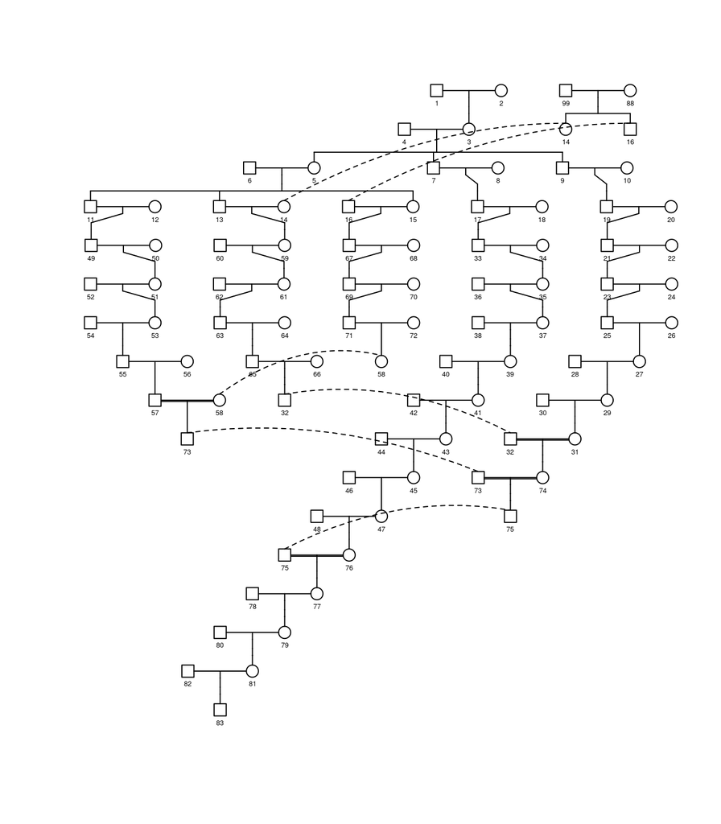

Figure 5.2: A pedigree diagram

```r
ped <- with(lukas,pedigree(id,father,mother,sex))
plot(ped,cex=0.4)
```

We then turn to the kinship calculation.

```r
# unordered individuals
gk1 <- kin.morgan(as.matrix(lukas[1:3]))
write.table(gk1$kin.matrix,"gap_1.txt",quote=FALSE)

library(kinship2)
kk1 <- kinship(lukas[,1],lukas[,2],lukas[,3])
write.table(kk1,"kinship_1.txt",quote=FALSE)

d <- gk1$kin.matrix-kk1
sum(abs(d))

# order individuals so that parents precede their children
library(pedigree)
op <- orderPed(lukas)
olukas <- lukas[order(op),]
gk2 <- kin.morgan(as.matrix(olukas[1:3]))

write.table(olukas,"olukas.csv",quote=FALSE)
write.table(gk2$kin.matrix,"gap_2.txt",quote=FALSE)

kk2 <- kinship(olukas[,1],olukas[,2],olukas[,3])
write.table(kk2,"kinship_2.txt",quote=FALSE)

z <- gk2$kin.matrix-kk2
sum(abs(z))
```

We see that in the first case,

```
> sum(abs(d))
[1] 2.443634
```

but in the second case, the result agrees with **kinship2**.

# 6 Study designs

I would like to highlight `fbsize`, `pbsize` and `ccsize` functions used for power/sample calculations in a genome-wide asssociatoin study as reported<sup>11</sup>,<sup>12</sup>,<sup>13</sup>.

It now has an experimental work via Shiny from `inst/shinygap`.

## 6.1 Family-based design

The example is as follows,

```r
options(width=150)
library(gap)
models <- data.frame(
  gamma = c(4,4,4,4, 2,2,2,2, 1.5,1.5,1.5,1.5),
  p     = c(0.01,0.10,0.50,0.80,
            0.01,0.10,0.50,0.80,
            0.01,0.10,0.50,0.80)
)
res <- t(mapply(function(g, p) {
  z <- fbsize(g, p)
  with(z, c(gamma, p, y, n1, pA, h1, n2, h2, n3, lambdao, lambdas))
}, models$gamma, models$p))
table1 <- as.data.frame(res)
names(table1) <- c("gamma","p","Y","N_asp","P_A","H1",
                   "N_tdt","H2","N_asp_tdt","L_o","L_s")
int_cols <- c("N_asp", "N_tdt", "N_asp_tdt")
dec_cols <- c("Y", "P_A", "H1", "H2", "L_o", "L_s")
table1[int_cols] <- lapply(table1[int_cols], ceiling)
table1[dec_cols] <- lapply(table1[dec_cols], round, 2)
knitr::kable(table1, caption = "Power/Sample size of family-based designs")
```

Table 6.1: Power/Sample size of family-based designs

| gamma | p | Y | N_asp | P_A | H1 | N_tdt | H2 | N_asp_tdt | L_o | L_s |
| --- | --- | --- | --- | --- | --- | --- | --- | --- | --- | --- |
| 4.0 | 0.01 | 0.52 | 6402 | 0.80 | 0.05 | 1201 | 0.11 | 257 | 1.08 | 1.09 |
| 4.0 | 0.10 | 0.60 | 277 | 0.80 | 0.35 | 165 | 0.54 | 53 | 1.48 | 1.54 |
| 4.0 | 0.50 | 0.58 | 446 | 0.80 | 0.50 | 113 | 0.42 | 67 | 1.36 | 1.39 |
| 4.0 | 0.80 | 0.53 | 3024 | 0.80 | 0.24 | 244 | 0.16 | 177 | 1.12 | 1.13 |
| 2.0 | 0.01 | 0.50 | 445964 | 0.67 | 0.03 | 6371 | 0.04 | 2155 | 1.01 | 1.01 |
| 2.0 | 0.10 | 0.52 | 8087 | 0.67 | 0.25 | 761 | 0.32 | 290 | 1.07 | 1.08 |
| 2.0 | 0.50 | 0.53 | 3753 | 0.67 | 0.50 | 373 | 0.47 | 197 | 1.11 | 1.11 |
| 2.0 | 0.80 | 0.51 | 17909 | 0.67 | 0.27 | 701 | 0.22 | 431 | 1.05 | 1.05 |
| 1.5 | 0.01 | 0.50 | 6944779 | 0.60 | 0.02 | 21138 | 0.03 | 8508 | 1.00 | 1.00 |
| 1.5 | 0.10 | 0.51 | 101926 | 0.60 | 0.21 | 2427 | 0.25 | 1030 | 1.02 | 1.02 |
| 1.5 | 0.50 | 0.51 | 27048 | 0.60 | 0.50 | 1039 | 0.49 | 530 | 1.04 | 1.04 |
| 1.5 | 0.80 | 0.51 | 101926 | 0.60 | 0.29 | 1820 | 0.25 | 1030 | 1.02 | 1.02 |

As for APOE4 and Alzheimer’s<sup>14</sup>

```r
g <- 4.5
p <- 0.15
alz <- data.frame(fbsize(g,p))
knitr::kable(alz,caption="Power/Sample size of study on Alzheimer's disease")
```

Table 6.2: Power/Sample size of study on Alzheimer’s disease

| gamma | p | y | n1 | pA | h1 | n2 | h2 | n3 | lambdao | lambdas |
| --- | --- | --- | --- | --- | --- | --- | --- | --- | --- | --- |
| 4.5 | 0.15 | 0.6256916 | 162.6246 | 0.8181818 | 0.4598361 | 108.994 | 0.6207625 | 39.97688 | 1.671594 | 1.784353 |

## 6.2 Population-based design

The example is as follows,

```r
library(gap)
kp <- c(0.01, 0.05, 0.10, 0.20)
models <- data.frame(
  gamma = c(4,4,4,4, 2,2,2,2, 1.5,1.5,1.5,1.5),
  p     = c(0.01,0.10,0.50,0.80,
            0.01,0.10,0.50,0.80,
            0.01,0.10,0.50,0.80)
)
res <- t(mapply(function(g, p) {
  ceiling(sapply(kp, function(k) pbsize(k, g, p)))
}, models$gamma, models$p))
table5 <- cbind(models, as.data.frame(res))
names(table5) <- c("gamma", "p", "p1", "p5", "p10", "p20")
knitr::kable(table5, caption = "Sample size of population-based design")
```

Table 6.3: Sample size of population-based design

| gamma | p | p1 | p5 | p10 | p20 |
| --- | --- | --- | --- | --- | --- |
| 4.0 | 0.01 | 46681 | 8959 | 4244 | 1887 |
| 4.0 | 0.10 | 8180 | 1570 | 744 | 331 |
| 4.0 | 0.50 | 10891 | 2091 | 991 | 441 |
| 4.0 | 0.80 | 31473 | 6041 | 2862 | 1272 |
| 2.0 | 0.01 | 403970 | 77530 | 36725 | 16323 |
| 2.0 | 0.10 | 52709 | 10116 | 4792 | 2130 |
| 2.0 | 0.50 | 35285 | 6772 | 3208 | 1426 |
| 2.0 | 0.80 | 79391 | 15237 | 7218 | 3208 |
| 1.5 | 0.01 | 1599920 | 307056 | 145448 | 64644 |
| 1.5 | 0.10 | 192105 | 36869 | 17465 | 7762 |
| 1.5 | 0.50 | 98013 | 18811 | 8911 | 3961 |
| 1.5 | 0.80 | 192105 | 36869 | 17465 | 7762 |

## 6.3 Case-cohort design

We obtain results for ARIC and EPIC studies.

```r
library(gap)
# ARIC study
n <- 15792; pD <- 0.03; p1 <- 0.25; alpha <- 0.05; beta <- 0.2
hr <- c(1.35, 1.40, 1.45); q <- c(1463, 722, 468) / n
aric <- data.frame(
  n, pD, p1, hr, q,
  power = signif(mapply(ccsize, n, q, pD, p1, log(hr),
                        MoreArgs = list(alpha = alpha, beta = beta, power = TRUE)), 3),
  ssize = mapply(ccsize, n, q, pD, p1, log(hr),
                 MoreArgs = list(alpha = alpha, beta = beta, power = FALSE))
)
aric
```

```
#>       n   pD   p1   hr          q power ssize
#> 1 15792 0.03 0.25 1.35 0.09264184   0.8  1463
#> 2 15792 0.03 0.25 1.40 0.04571935   0.8   722
#> 3 15792 0.03 0.25 1.45 0.02963526   0.8   468
```

```r
# EPIC study
n <- 25000; q <- 0.1; alpha <- 5e-8; beta <- 0.2
epic <- subset(
  transform(
    expand.grid(pD = c(0.3, 0.2, 0.1, 0.05),
                p1 = seq(0.1, 0.5, 0.1),
                hr = seq(1.1, 1.4, 0.1)),
    n = n,
    alpha = formatC(alpha, format = "e", digits = 2),
    ssize = mapply(ccsize, n, q, pD, p1, log(hr),
                   MoreArgs = list(alpha = alpha, beta = beta, power = FALSE))
  ),
  !is.na(ssize) & ssize > 0
)
knitr::kable(epic,caption="Sample size of case-cohort designs")
```

Table 6.4: Sample size of case-cohort designs

|  | pD | p1 | hr | n | alpha | ssize |
| --- | --- | --- | --- | --- | --- | --- |
| 25 | 0.3 | 0.2 | 1.2 | 25000 | 5.00e-08 | 21529 |
| 29 | 0.3 | 0.3 | 1.2 | 25000 | 5.00e-08 | 11095 |
| 33 | 0.3 | 0.4 | 1.2 | 25000 | 5.00e-08 | 8596 |
| 34 | 0.2 | 0.4 | 1.2 | 25000 | 5.00e-08 | 20131 |
| 37 | 0.3 | 0.5 | 1.2 | 25000 | 5.00e-08 | 7995 |
| 38 | 0.2 | 0.5 | 1.2 | 25000 | 5.00e-08 | 17120 |
| 41 | 0.3 | 0.1 | 1.3 | 25000 | 5.00e-08 | 14391 |
| 45 | 0.3 | 0.2 | 1.3 | 25000 | 5.00e-08 | 5099 |
| 46 | 0.2 | 0.2 | 1.3 | 25000 | 5.00e-08 | 7725 |
| 49 | 0.3 | 0.3 | 1.3 | 25000 | 5.00e-08 | 3490 |
| 50 | 0.2 | 0.3 | 1.3 | 25000 | 5.00e-08 | 4548 |
| 53 | 0.3 | 0.4 | 1.3 | 25000 | 5.00e-08 | 2934 |
| 54 | 0.2 | 0.4 | 1.3 | 25000 | 5.00e-08 | 3648 |
| 55 | 0.1 | 0.4 | 1.3 | 25000 | 5.00e-08 | 13479 |
| 57 | 0.3 | 0.5 | 1.3 | 25000 | 5.00e-08 | 2786 |
| 58 | 0.2 | 0.5 | 1.3 | 25000 | 5.00e-08 | 3422 |
| 59 | 0.1 | 0.5 | 1.3 | 25000 | 5.00e-08 | 10837 |
| 61 | 0.3 | 0.1 | 1.4 | 25000 | 5.00e-08 | 5732 |
| 62 | 0.2 | 0.1 | 1.4 | 25000 | 5.00e-08 | 9277 |
| 65 | 0.3 | 0.2 | 1.4 | 25000 | 5.00e-08 | 2613 |
| 66 | 0.2 | 0.2 | 1.4 | 25000 | 5.00e-08 | 3164 |
| 67 | 0.1 | 0.2 | 1.4 | 25000 | 5.00e-08 | 8615 |
| 69 | 0.3 | 0.3 | 1.4 | 25000 | 5.00e-08 | 1882 |
| 70 | 0.2 | 0.3 | 1.4 | 25000 | 5.00e-08 | 2152 |
| 71 | 0.1 | 0.3 | 1.4 | 25000 | 5.00e-08 | 3776 |
| 73 | 0.3 | 0.4 | 1.4 | 25000 | 5.00e-08 | 1611 |
| 74 | 0.2 | 0.4 | 1.4 | 25000 | 5.00e-08 | 1805 |
| 75 | 0.1 | 0.4 | 1.4 | 25000 | 5.00e-08 | 2824 |
| 77 | 0.3 | 0.5 | 1.4 | 25000 | 5.00e-08 | 1538 |
| 78 | 0.2 | 0.5 | 1.4 | 25000 | 5.00e-08 | 1713 |
| 79 | 0.1 | 0.5 | 1.4 | 25000 | 5.00e-08 | 2606 |

# 7 Graphics

Some figures from the documentation may be of interest.

## 7.1 Genome-wide association

The following code is used to obtain a Q-Q plot via `qqunif` function,

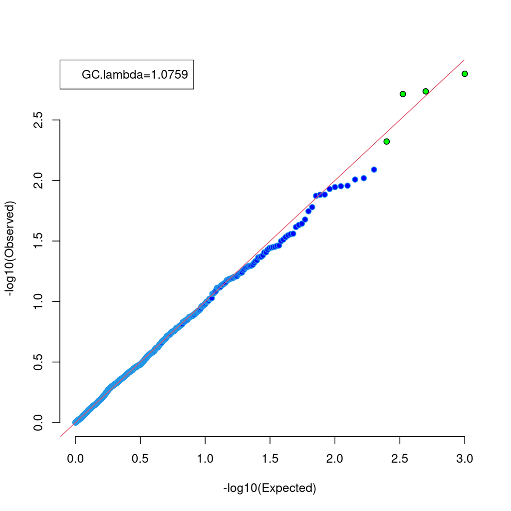

Figure 7.1: A Q-Q plot

```r
library(gap)
u_obs <- runif(1000)
r <- qqunif(u_obs,pch=21,bg="blue",bty="n")
u_exp <- r$y
hits <- u_exp >= 2.30103
points(r$x[hits],u_exp[hits],pch=21,bg="green")
legend("topleft",sprintf("GC.lambda=%.4f",gc.lambda(u_obs)))
```

Based on a chicken genome scan data, the code below generates a Manhattan plot, demonstrating the use of gaps to separate chromosomes.

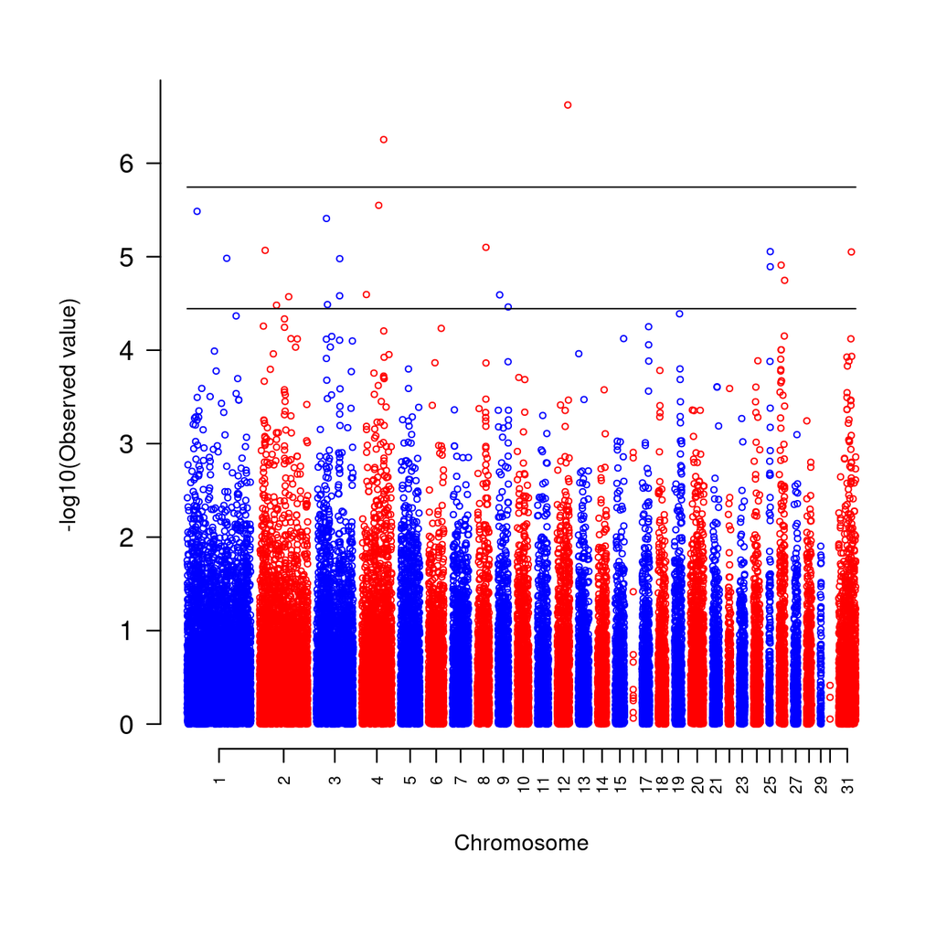

Figure 7.2: A genome-wide association study on chickens

```r
w4 <- w4[order(w4$chr, w4$pos), ]
colors <- c(rep(c("blue","red"),15),"red")
suggestiveline <- -log10(3.60036E-05)
genomewideline <- -log10(1.8E-06)
mhtplot(
  w4,
  control = mht.control(
    colors  = colors,
    gap     = 1000,
    cex     = 0.6,
    cutoffs = c(suggestiveline,genomewideline),
    lab.cex = 0.6,
    xline   = 3,
    yline   = 3
  ),
  pch = 19,
  srt = 0
)
```

The code below obtains a Manhattan plot with gene annotation<sup>15</sup>,

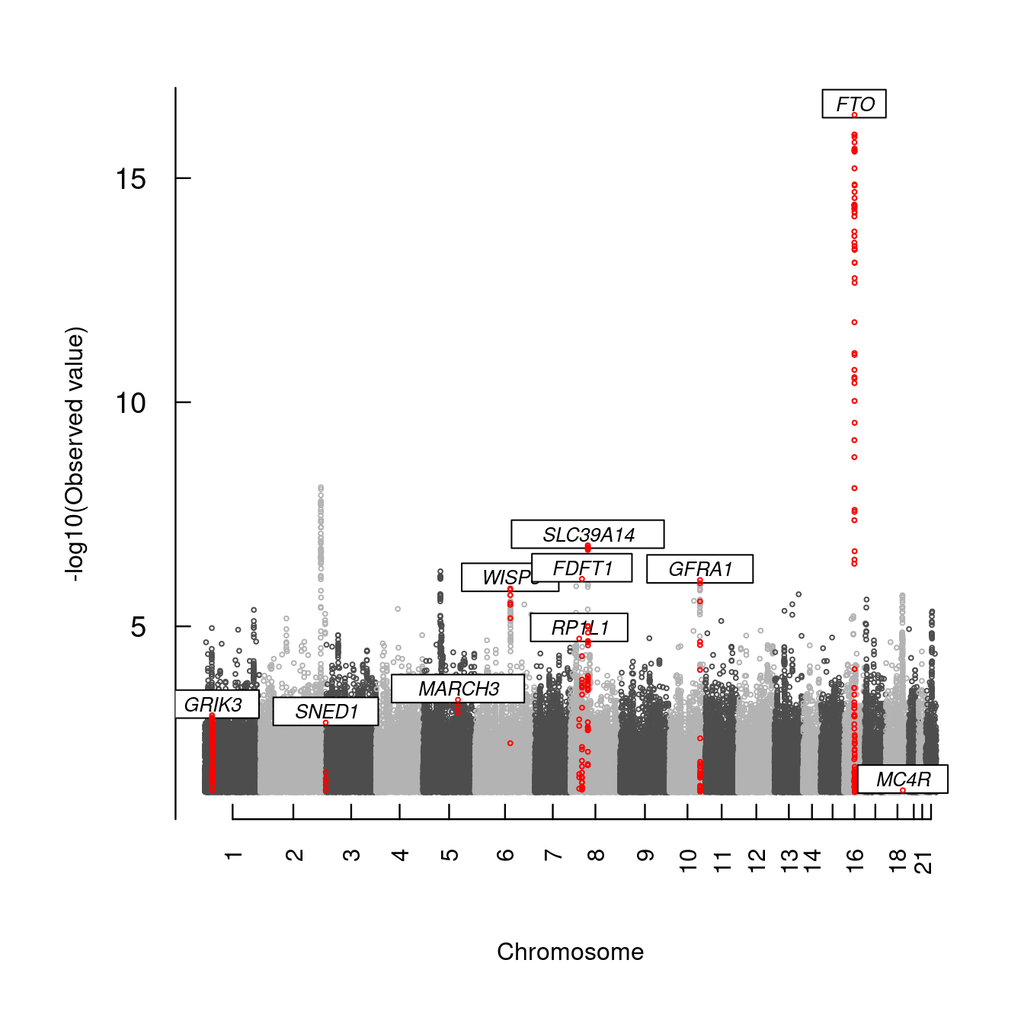

Figure 7.3: A Manhattan plot with gene annotation

```r
data <- with(mhtdata,cbind(chr,pos,p))
glist <- c("IRS1","SPRY2","FTO","GRIK3","SNED1","HTR1A","MARCH3","WISP3",
           "PPP1R3B","RP1L1","FDFT1","SLC39A14","GFRA1","MC4R")
hdata <- subset(mhtdata,gene%in%glist)[c("chr","pos","p","gene")]
hcolor <- rep("red",length(glist))
ops <- mht.control(axis.tck=0.02,cex=0.4,lab.cex=0.8,xline=4)
hops <- hmht.control(data=hdata,cex=0.8,colors=hcolor,boxed=TRUE)
mhtplot(data,ops,hops,pch=19)
```

All these look familiar, so revised form of the function called `mhtplot2` was created, allowing for more sophisticated coloring schemes, using prespecified fonts, etc. Please refer to the function’s documentation example.

We could also go further with a circos Manhattan plot,

```
#> Note: 11 points are out of plotting region in sector 'chr16', track '3'.
```

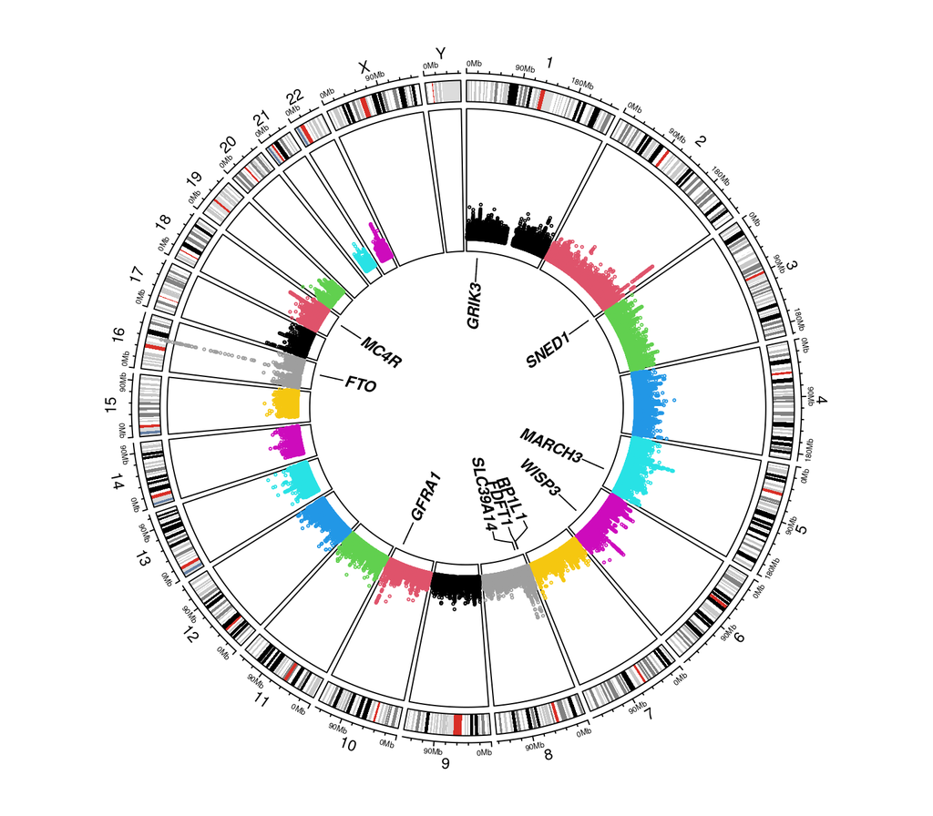

Figure 7.4: A circos Manhattan plot

```r
circos.mhtplot(mhtdata, glist)
```

and a version with y-axis,

```r
require(gap.datasets)
library(dplyr)
testdat <- mhtdata[c("chr","pos","p","gene","start","end")] %>%
           rename(log10p=p) %>%
           mutate(chr=paste0("chr",chr),log10p=-log10(log10p))
dat <- mutate(testdat,start=pos,end=pos) %>%
       select(chr,start,end,log10p)
labs <- subset(testdat,gene %in% glist) %>%
        group_by(gene,chr,start,end) %>%
        summarize() %>%
        mutate(cols="blue") %>%
        select(chr,start,end,gene,cols)
```

[output not shown]

```
#> Note: 43 points are out of plotting region in sector 'chr16', track '5'.
```

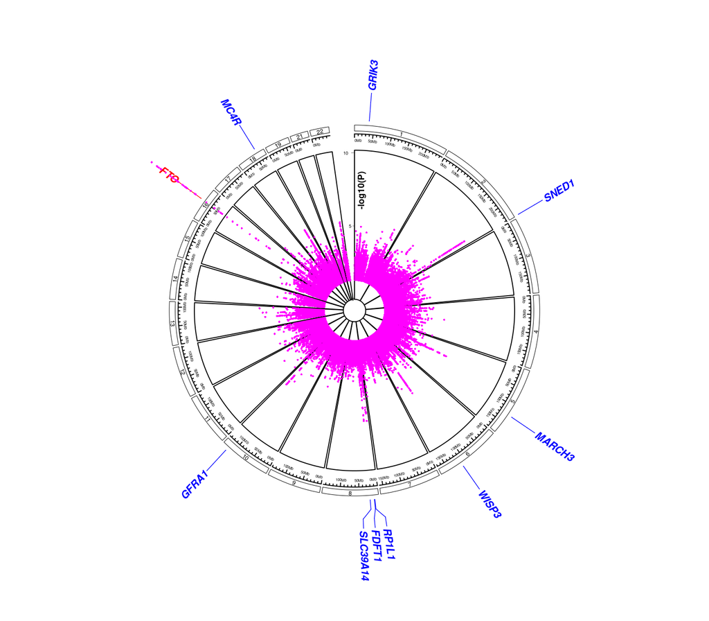

Figure 7.5: Another circos Manhattan plot

```r
labs[2,"cols"] <- "red"
ticks <- 0:2*5
circos.mhtplot2(dat,labs,ticks=ticks,ymax=max(ticks))
```

As a side note, the data is used by `manhattanly`.

```r
#{r mhttest, fig.cap="Manhattanly plot", fig.height=8, fig.width=8, plotly=TRUE}
library(manhattanly)
mhttest <- manhattanly(mhtdata, chr = "chr", bp = "pos",
                       snp = "rsn", annotation1 = "gene", suggestiveline = TRUE,
                       annotation2 = "rsn", p = "p")
mhttest
htmlwidgets::saveWidget(mhttest,"mhttest.html")
```

We now experiment with Miami plot,

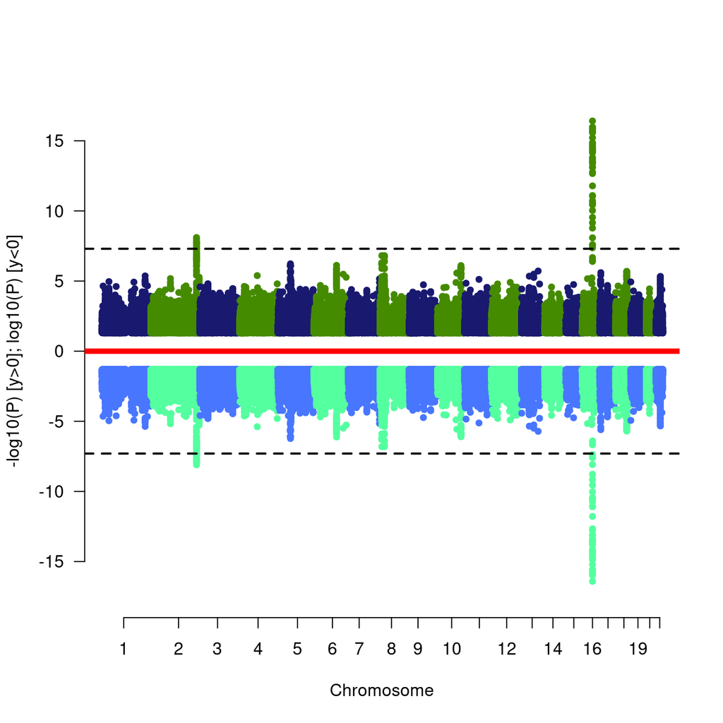

Figure 7.6: Miami plots

```r
mhtdata <- within(mhtdata,{pr=p})
miamiplot(mhtdata,chr="chr",bp="pos",p="p",pr="pr",snp="rsn")
```

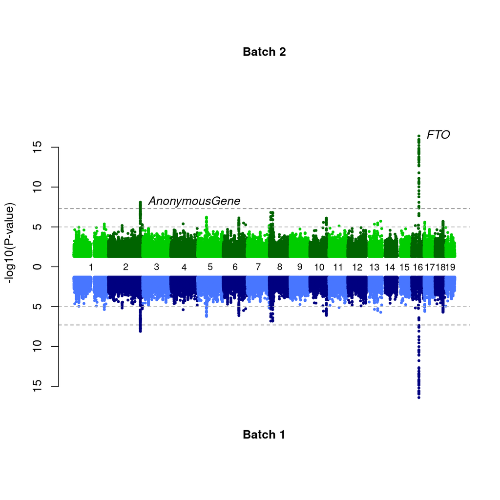

Figure 7.7: Miami plots

```r
# An alternative implementation
gwas <- select(mhtdata,chr,pos,p) %>%
        mutate(z=qnorm(p/2))
chrmaxpos <- miamiplot2(gwas,gwas,name1="Batch 2",name2="Batch 1",z1="z",z2="z")
labelManhattan(chr=c(2,16),pos=c(226814165,52373776),name=c("AnonymousGene","FTO"),gwas,gwasZLab="z",chrmaxpos=chrmaxpos)
```

and a truncated Manhattan plot, noting that only data points with -log10(P)>=2 are shown,

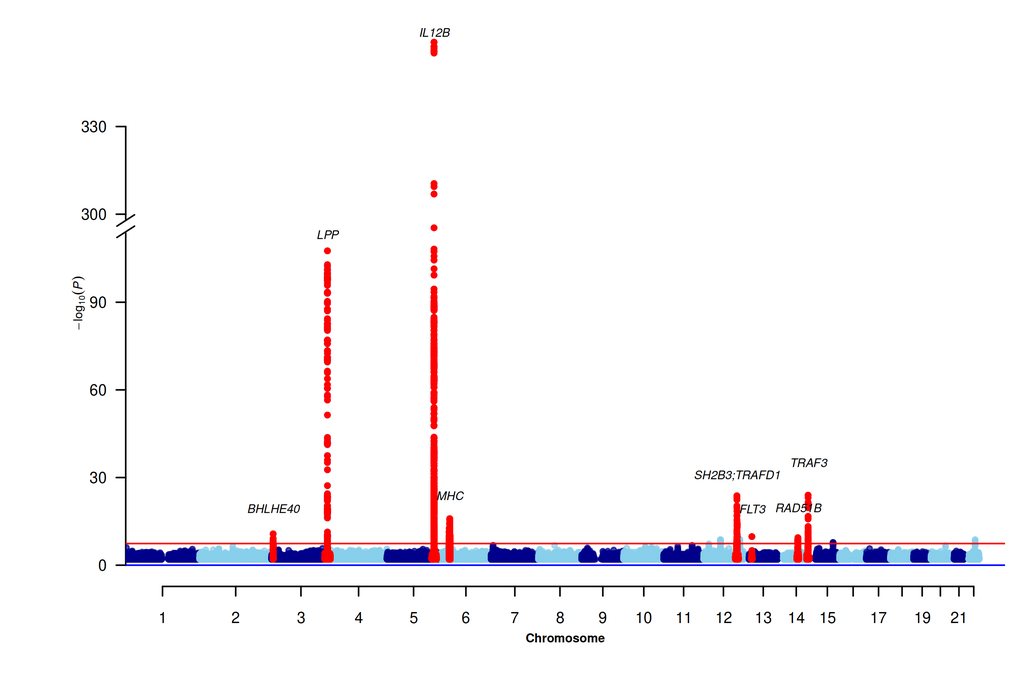

Figure 7.8: Association of IL-12B

```r
hl <- c("BHLHE40", "LPP", "IL12B", "MHC", "SH2B3;TRAFD1", "FLT3", "RAD51B", "TRAF3")
dat <- IL.12B_truncated
dat <- dat[order(dat$Chromosome, dat$Position), ]
Cairo::CairoPNG("IL-12B_mhtplot.trunc.png", width = 9, height = 6, units = "in", dpi = 300)
screen_like <- TRUE
cex.scale <- if (screen_like) 0.85 else 1
space.scale <- if (screen_like) 0.85 else 1
par(mar = c(5, 6.5, 1, 1),cex = cex.scale)
d <- mhtplot.trunc(
  dat,
  chr = "Chromosome",
  bp = "Position",
  log10p = "log10P",
  snp = "MarkerName",
  highlight = hl,
  suggestiveline = FALSE,
  genomewideline = -log10(5e-8),
  annotateTop = FALSE,
  annotatelog10P = Inf,
  y.brk1 = 115,
  y.brk2 = 300,
  trunc.yaxis = TRUE,
  cex.axis = 1.1 * cex.scale,
  cex = 0.75 * cex.scale,
  cex.text = 0.85 * cex.scale,
  y.ax.space = 35 * space.scale,
  col = c("blue4", "skyblue")
)
hl.df <- d[d$SNP %in% hl, ]
hl.df <- hl.df[order(hl.df$log10P, decreasing = TRUE), ]
base.space <- 0.9 * space.scale
hl.df$offset <- (seq_len(nrow(hl.df)) - 1) * base.space
if (all(c("FLT3", "TRAF3") %in% hl.df$SNP)) {
  i1 <- which(hl.df$SNP == "FLT3")
  i2 <- which(hl.df$SNP == "TRAF3")
  hl.df$offset[i2] <- hl.df$offset[i1] + 2.2 * base.space
}
text(x = hl.df$pos, y = hl.df$log10P + hl.df$offset,
  labels = hl.df$SNP, cex = 0.85 * cex.scale, font = 3, pos = 3)
dev.off()
```

The code below obtains a regional association plot with the `asplot` function,

```r
asplot(CDKNlocus, CDKNmap, CDKNgenes, best.pval=5.4e-8, sf=c(3,6))
```

```
#> - CDKN2A
#> - CDKN2B
```

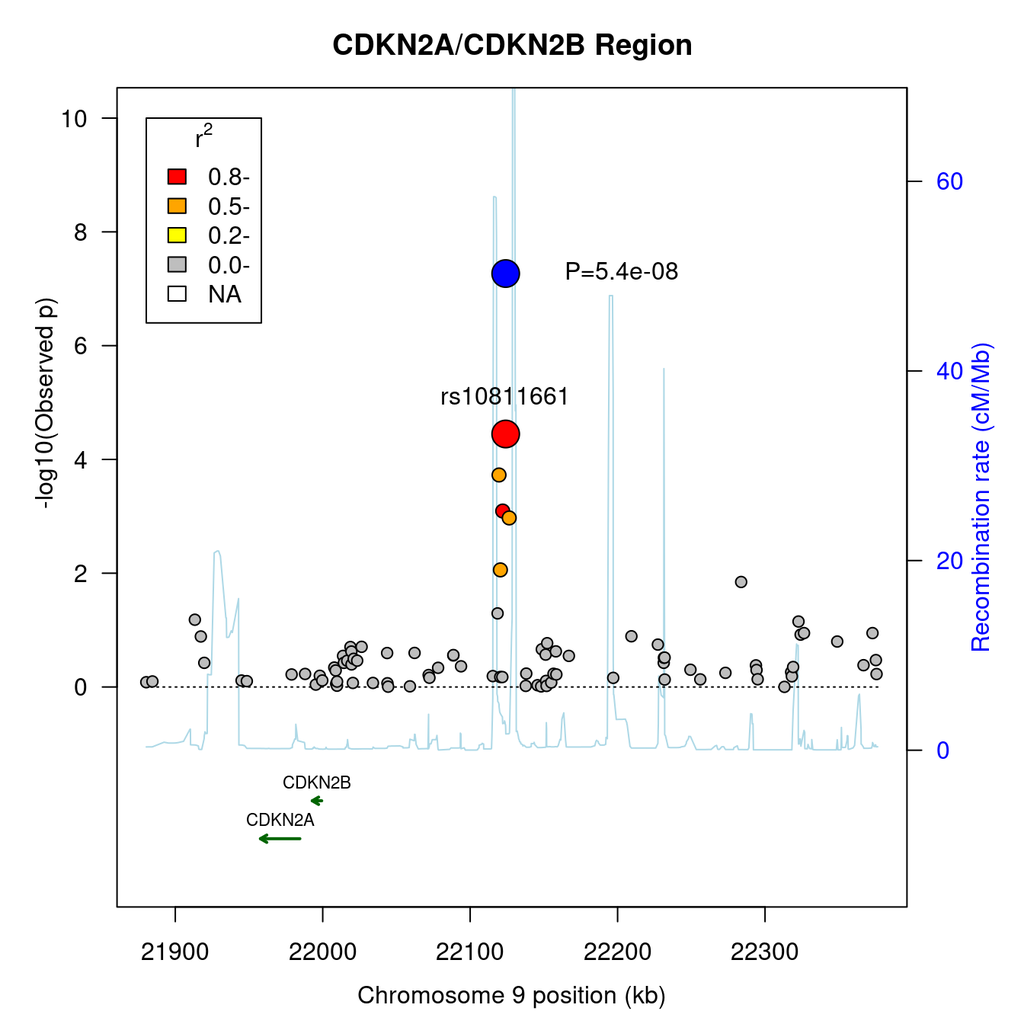

Figure 7.9: A regional association plot

```r
title("CDKN2A/CDKN2B Region")
```

The function predates the currently popular **locuszoom** software but leaves the option open for generating such plots on the fly and locally.

Note that all these can serve as templates to customize features of your own.

## 7.2 Copy number variation

A plot of copy number variation (CNV) is shown here,

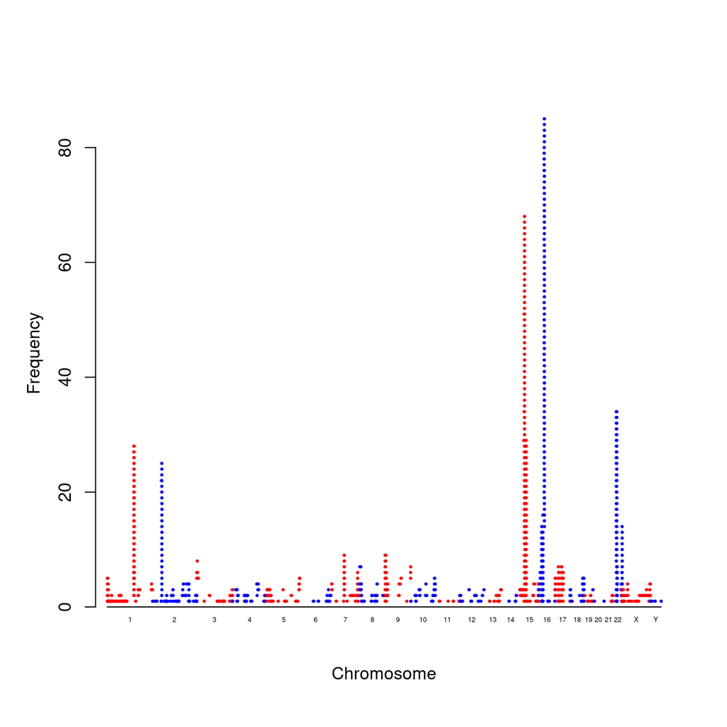

Figure 7.10: A CNV plot

```r
cnvplot(gap.datasets::cnv)
```

## 7.3 Effect size plot

The code below obtains an effect size plot via the `ESplot` function.

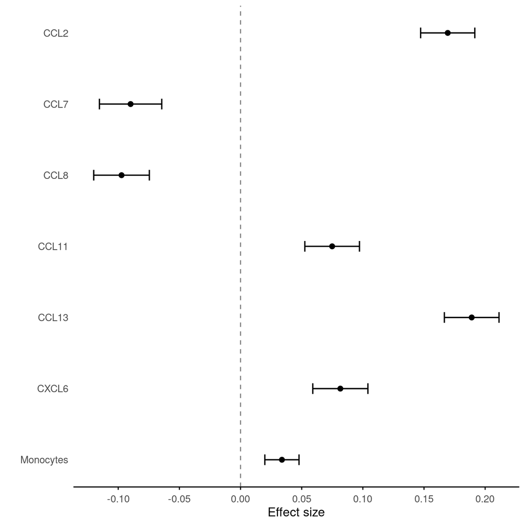

Figure 7.11: rs12075 and traits

```r
library(gap)
rs12075 <- data.frame(id=c("CCL2","CCL7","CCL8","CCL11","CCL13","CXCL6","Monocytes"),
                      b=c(0.1694,-0.0899,-0.0973,0.0749,0.189,0.0816,0.0338387),
                      se=c(0.0113,0.013,0.0116,0.0114,0.0114,0.0115,0.00713386))
ESplot(rs12075)
```

## 7.4 Forest plot

It draws many forest plots given a list of variants, e.g.,

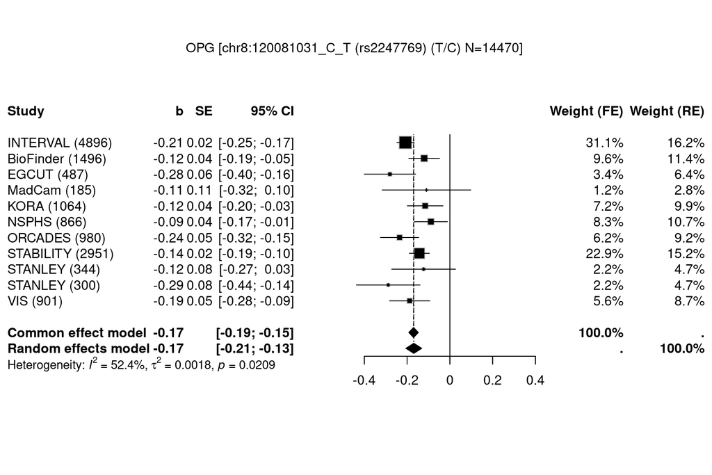

Figure 7.12: Forest plots

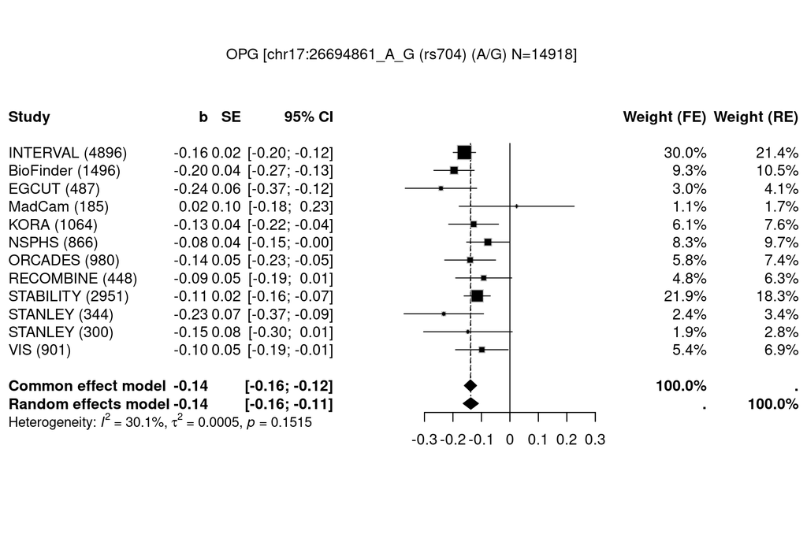

Figure 7.13: Forest plots

```r
data(OPG,package="gap.datasets")
meta::settings.meta(method.tau="DL")
METAL_forestplot(OPGtbl,OPGall,OPGrsid,width=6.75,height=5,digits.TE=2,digits.se=2,
                 col.diamond="black",col.inside="black",col.square="black")
```

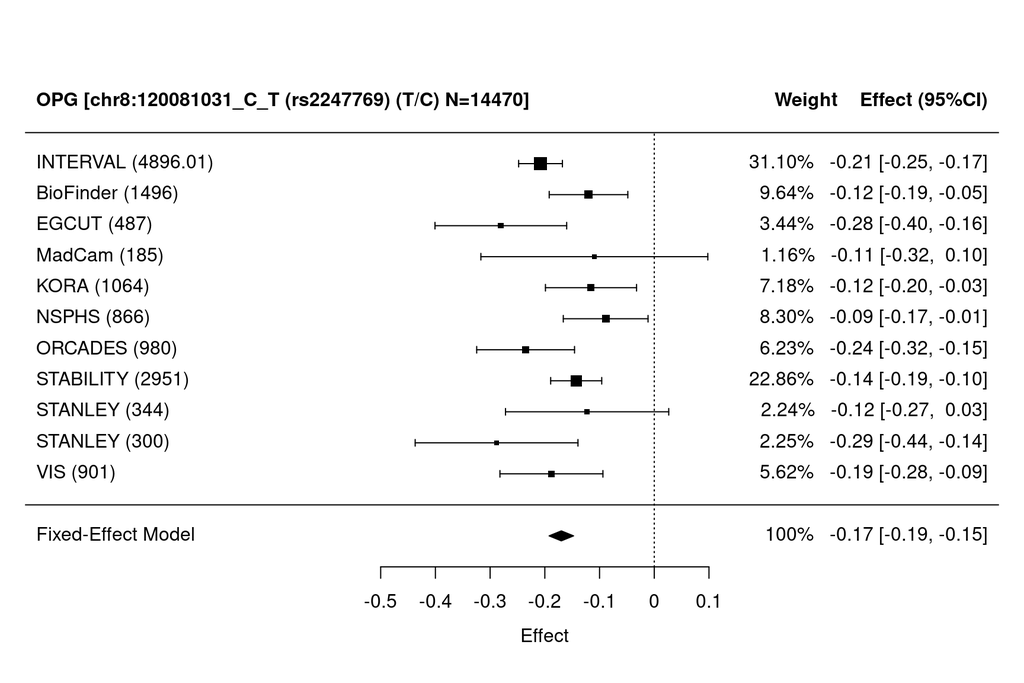

Figure 7.14: Forest plots

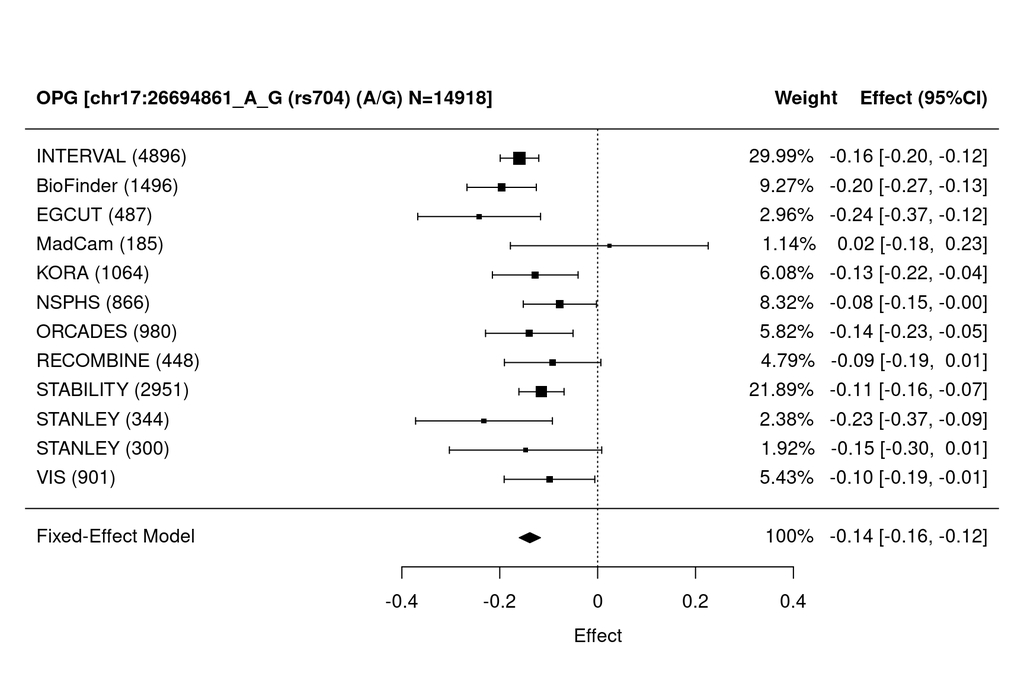

Figure 7.15: Forest plots

```r
METAL_forestplot(OPGtbl,OPGall,OPGrsid,package="metafor",method="FE",xlab="Effect",
                 showweights=TRUE)
```

# 8 Significance

Our focus is on z ~ Normal(0,1), whose schematic diagram is shown below.

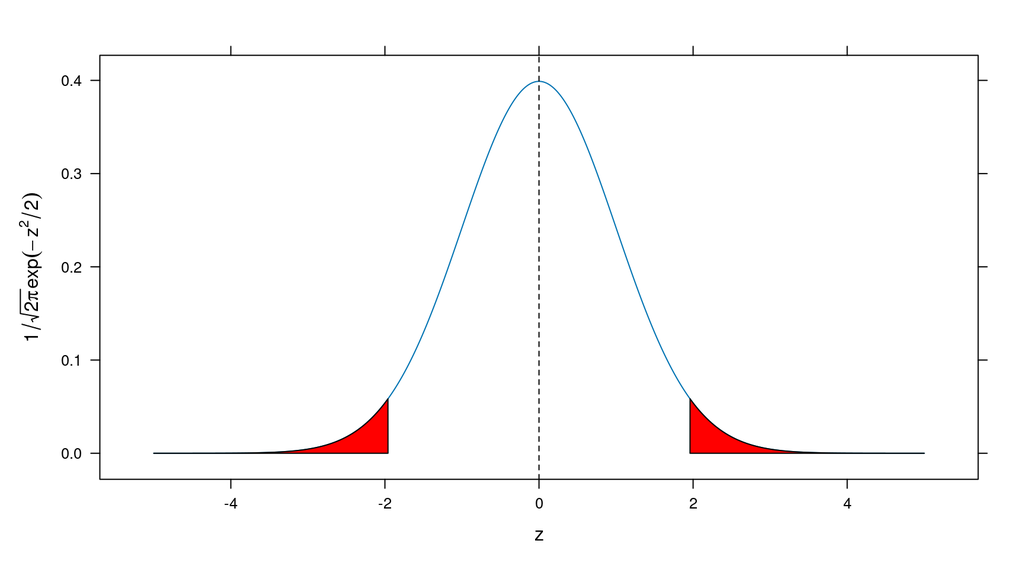

Figure 8.1: Normal(0,1) distribution

The associate R function is `z <- function(p) qnorm(p/2,lower.tail=FALSE)`.

When z is very large, its corresponding p value is very small. A genomewide significance is declared at 0.05/1000000=5e-8 with Bonferroni correction assuming 1 million SNPs are tested. This short note describes how to get -log10(p), which can be used in a Q-Q plot and software such as DEPICT<sup>16</sup>. The solution here is generic since z is also the square root of a chi-squared statistic, for instance.

## 8.1 log(p) and log10(p)

First thing first, here are the answers for log(p) and log10(p) given z,

```r
# log(p) for a standard normal deviate z based on log()
logp <- function(z) log(2)+pnorm(-abs(z), lower.tail=TRUE, log.p=TRUE)

# log10(p) for a standard normal deviate z based on log()
log10p <- function(z) log(2, base=10)+pnorm(-abs(z), lower.tail=TRUE, log.p=TRUE)/log(10)
```

Note `logp()` will be used for functions such as `qnorm()` as in function `cs()` whereas `log10p()` is more appropriate for Manhattan plot and used in `sentinels()`.

## 8.2 Rationale

We start with z=1.96 whose corresponding p value is approximately 0.05.

```r
2*pnorm(-1.96,lower.tail=TRUE)
```

giving an acceptable value 0.04999579, so we proceed to get log10(p)

```r
log10(2)+log10(pnorm(-abs(z),lower.tail=TRUE))
```

leading to the expression above from the fact that log10(X)=log(X)/log(10) since log(), being the natural log function, ln() – so log(exp(1)) = 1, in R, works far better on the numerator of the second term. The use of -abs() just makes sure we are working on the lower tail of the standard Normal distribution from which our p value is calculated.

## 8.3 Benchmark

Now we have a stress test,

```r
z <- 20000
-log10p(z)
```

giving -log10(p) = 86858901.

## 8.4 Multiple precision arithmetic

We would be curious about the p value itself as well, which is furnished with the Rmpfr package

```r
require(Rmpfr)
2*pnorm(mpfr(-abs(z),100),lower.tail=TRUE,log.p=FALSE)
mpfr(log(2),100) + pnorm(mpfr(-abs(z),100),lower.tail=TRUE,log.p=TRUE)
```

giving p = 1.660579603192917090365313727164e-86858901 and -log(p) = -200000010.1292789076808554854177, respectively. To carry on we have -log10(p) = -log(p)/log(10)=86858901.

To make -log10(p) usable in R we obtain it directly through

```r
as.numeric(-log10(2*pnorm(mpfr(-abs(z),100),lower.tail=TRUE)))
```

which actually yields exactly the same 86858901.

If we go very far to have z=50,000. then -log10(p)=542868107 but we have less luck with Rmpfr.

One may wonder the P value in this case, which is 6.6666145952e-542868108 or simply 6.67e-542868108.

The magic function for doing this is defined as follows,

```r
pvalue <- function (z, decimals = 2)
{
    lp <- -log10p(z)
    exponent <- ceiling(lp)
    base <- 10^-(lp - exponent)
    paste0(round(base, decimals), "e", -exponent)
}
```

and it is more appropriate to express p values in scientific format so they can be handled as follows,

```r
log10pvalue <- function(p=NULL,base=NULL,exponent=NULL)
{
  if(!is.null(p))
  {
    p <- format(p,scientific=TRUE)
    p2 <- strsplit(p,"e")
    base <- as.numeric(lapply(p2,"[",1))
    exponent <- as.numeric(lapply(p2,"[",2))
  } else if(is.null(base) | is.null(exponent)) stop("base and exponent should both be specified")
  log10(base)+exponent
}
```

One can also derive logpvalue for natural base (e) similarly.

We end with a quick look-up table

```r
require(gap)
zlist <- c(5,10,30,40,50,100,500,1000,2000,3000,5000)
zp <- sapply(zlist,function(z) {c(z,pvalue(z),logp(z),log10p(z))})
rownames(zp) <- c("z","P","log(P)","log10(P)")
knitr::kable(t(zp),caption="z, P, log(P) and log10(P)")
```

Table 8.1: z, P, log(P) and log10(P)

| z | P | log(P) | log10(P) |
| --- | --- | --- | --- |
| 5 | 5.73e-7 | -14.3718512134288 | -6.24161567672667 |
| 10 | 1.52e-23 | -52.5381379699525 | -22.8170234098221 |
| 30 | 9.81e-198 | -453.628096775783 | -197.008179265997 |
| 40 | 7.31e-350 | -803.915294833194 | -349.135976463682 |
| 50 | 2.16e-545 | -1254.13821395886 | -544.665305866333 |
| 100 | 2.69e-2174 | -5004.83106151365 | -2173.57051287337 |
| 500 | 2.47e-54290 | -125006.440403451 | -54289.6072695865 |
| 1000 | 4.58e-217151 | -500007.133547632 | -217150.339011999 |
| 2000 | 4.34e-868593 | -2000007.82669406 | -868592.362896546 |
| 3000 | 1.8e-1954329 | -4500008.23215903 | -1954328.74374587 |
| 5000 | 1.51e-5428685 | -12500008.7429846 | -5428684.82082061 |

## 8.5 Application

**The `mhtplot.trunc()` function accepts three types of arguments:**

In all three cases, a log10(P) counterpart is obtained internally and to accommodate extreme value, the y-axis allows for truncation leaving out a given range to highlight the largest.

See the IL-12B example above.

# 9 Linear regression

Several functions related to linear regression are detailed here.

## 9.1 Some preparations

Let $\mbox{x} = SNP\ dosage$. Note that $\mbox{Var}(\mbox{x})=2f(1-f)$, $f=MAF$ or $1-MAF$ by symmetry.

Our linear regression model is $\mbox{y}=a + b\mbox{x} + e$. We have $\mbox{Var}(\mbox{y}) = b^2\mbox{Var}(\mbox{x}) + \mbox{Var}(e)$. Moreover, $\mbox{Var}(b)=\mbox{Var}(e)(\mbox{x}'\mbox{x})^{-1}=\mbox{Var}(e)/S_\mbox{xx}$, we have $\mbox{Var}(e) = \mbox{Var}(b)S_\mbox{xx} = N \mbox{Var}(b) \mbox{Var}(\mbox{x})$. Consequently, let $z = {b}/{SE(b)}$, we have

$$\begin{eqnarray*}
\mbox{Var}(\mbox{y}) &=& \mbox{Var}(\mbox{x})(b^2+N\mbox{Var}(b)) \hspace{100cm} \cr
&=& \mbox{Var}(\mbox{x})\mbox{Var}(\mbox{b})(z^2+N) \cr
&=& 2f(1-f)(z^2+N)\mbox{Var}(b)
\end{eqnarray*}$$

Moreover, the mean and the variance of the multiple correlation coefficient or the coefficient of determination ($R^2$) are known<sup>17</sup> to be ${1}/{(N-1)}$ and ${2(N-2)}/{\left[(N-1)^2(N+1)\right]}$, respectively.

We also need some established results of a ratio (R/S)[^1], i.e., the mean

$$\begin{align}
E(R/S) \approx \frac{\mu_R}{\mu_S}-\frac{\mbox{Cov}(R,S)}{\mu_S^2}+\frac{\sigma_S^2\mu_R}{\mu_S^3} \hspace{100cm}
\tag{9.1}
\end{align}$$

and more importantly the variance

$$\begin{align}
\mbox{Var}(R/S) \approx \frac{\mu_R^2}{\mu_S^2} \left[
\frac{\sigma_R^2}{\mu_R^2} -2\frac{\mbox{Cov}(R,S)}{\mu_R\;\mu_S}
+\frac{\sigma_S^2}{\mu_S^2} \right] \hspace{100cm}
\tag{9.2}
\end{align}$$

where $\mu_R$, $\mu_S$, $\sigma_R^2$, $\sigma_S^2$ are the means and the variances for R and S, respectively.

Finally, we need some facts about $\chi_1^2$, $\chi^2$ distribution of one degree of freedom. For $z \sim N(0,1)$, $z^2\sim \chi_1^2$, whose mean and variance are 1 and 2, respectively.

We now have the following results.

## 9.2 Proportion of variance explained

We have

$$\begin{align}
\mbox{PVE}_{\mbox{linear regression}} & = \frac{\mbox{Var}(b\mbox{x})}{\mbox{Var}(\mbox{y})} \hspace{100cm} \\
& = \frac{\mbox{Var}(\mbox{x})b^2}{\mbox{Var}(\mbox{x})(b^2+N\mbox{Var}(b))} \\
& = \frac{\mbox{z}^2}{\mbox{z}^2+N}
\tag{9.3}
\end{align}$$

On the other hand, for a simple linear regression $R^2\equiv r^2$ where $r$ is the Pearson correlation coefficient, which is readily from the $t$-statistic of the regression slope, i.e., $r={t}/{\sqrt{t^2+N-2}}$. so assuming $t \equiv \ z \sim \chi_1^2$

$$\begin{align}
\mbox{PVE}_{t-\mbox{statistic}} & = \frac{\chi^2}{\chi^2+N-2} \hspace{100cm}
\tag{9.4}
\end{align}$$

To obtain coherent estimates of the asymptotic means and variances of both forms we resort to variance of a ratio (R/S). All the required elements are listed in a table below.

| Characteristics | Linear regression | $t$-statistic |
| --- | --- | --- |
| $\mu_R$ | 1 | 1 |
| $\sigma_R^2$ | 2 | 2 |
| $\mu_S$ | $N+1$ | $N-1$ |
| $\sigma_S^2$ | 2 | 2 |
| $\mbox{Cov}(R,S)$ | 2 | 2 |

then we have the means and the variances for PVE.

| Characteristics | Linear regression | $t$-statistic |
| --- | --- | --- |
| mean | $\frac{1}{N+1}\left[1-\frac{2}{N+1}+\frac{2}{(N+1)^2}\right]$ | $\frac{1}{N-1}\left[1-\frac{2}{N-1}+\frac{2}{(N-1)^2}\right]$ |
| variance | $\frac{2}{(N+1)^2}\left[1-\frac{1}{N+1}\right]^2$ | $\frac{2}{(N-1)^2}\left[1-\frac{1}{N-1}\right]^2$ |

Finally, our approximation of PVE for a protein with $T$ independent pQTLs from the meta-analysis

| Characteristics | Linear regression | $t$-statistic |
| --- | --- | --- |
| estimate | $\sum_{i=1}^T{\frac{\chi_i^2}{\chi_i^2+N_i}}$ | $\sum_{i=1}^T{\frac{\chi_i^2}{\chi_i^2+N_i-2}}$ |
| variance | $\sum_{i=1}^T\frac{2}{(N_i+1)^2}$ | $\sum_{i=1}^T\frac{2}{(N_i-1)^2}$ |

Therefore they differ from the asymptotic results<sup>17</sup> by ratios of $(N-2)(N+1)/(N-1)^2$ and $(N-2)/(N+1)$ for linear regression and $t$-statistic, respectively.

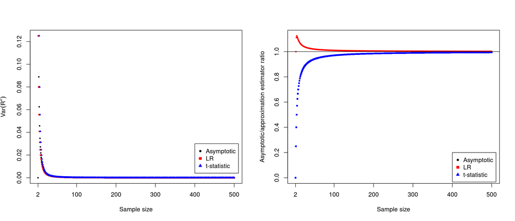

Figure 9.1: Comparisons of Var($R^2$) estimates

## 9.3 Effect size and standard error

When $\mbox{Var}(\mbox{y})=1$, as in cis eQTLGen<sup>18</sup> data, we have $b$ and its standard error (se) as follows,

$$\begin{align}
b & = z/d \hspace{100cm} \\
se & = 1/d
\tag{9.5}
\end{align}$$

where $d = \sqrt{2f(1-f)(z^2+N)}$.

Now three functions are in place.

## 9.4 get_b_se

A record of the eQTLGen data is shown below

```
        SNP    Pvalue SNPChr  SNPPos AssessedAllele OtherAllele Zscore
 rs1003563 2.308e-06     12 6424577              A           G 4.7245
            Gene GeneSymbol GeneChr GenePos NrCohorts NrSamples         FDR
 ENSG00000111321       LTBR      12 6492472        34     23991 0.006278872
 BonferroniP hg19_chr hg19_pos AlleleA AlleleB allA_total allAB_total
           1       12  6424577       A       G       2574        8483
 allB_total AlleleB_all
       7859   0.6396966
```

from which we obtain the effect size and its standard error as follows,

```r
get_b_se(0.6396966,23991,4.7245)
```

```
#>               b          se
#> [1,] 0.04490488 0.009504684
```

## 9.5 get_pve_se

This function obtains proportion of explained variation (PVE) from n, z; its standard error is based on variance of the ratio (correction=TRUE) or $r^2$.

## 9.6 get_sdy

We continue with the eQTLGen example above,

```r
get_sdy(0.6396966,23991,0.04490488,0.009504684)
```

```
#> [1] 1
```

and indeed the eQTLGen data were standardized.

# 10 Sentinels of association

## 10.1 Identification

Following an earlier implementation called `sentinels`, a distance-based signal identification based on GWAS summary statistics is avaialable from `qtlFinder` function; to avoid the overhead of data-loading it works on a preselected list of variants from a GWAS and in this case a METAL output file.

## 10.2 Fine-mapping

The function `cs` obtains credible set.

```r
# zcat METAL/4E.BP1-1.tbl.gz | \
# awk 'NR==1 || ($1==4 && $2 >= 187158034 - 1e6 && $2 < 187158034 + 1e6)' >  4E.BP1.z
tbl <- within(read.delim("4E.BP1.z"),{logp <- logp(Effect/StdErr)})
z <- cs(tbl)
l <- cs(tbl,log_p="logp")
```

Note in particular that the implementation intends to avoid the naive summation in scenarios such as proteogenomic analysis containing exceptionally large BFs.

# 11 Polygenic modeling

In line with the recent surge of interest in the polygenic models, a separate vignette is available through `vignette("h2",package="gap.examples")` demonstrating aspect of the models on heritability. Utility Functions `h2G`, `h2GE` and `h2l` are briefly documented. Functions `h2.jags` and `hwe.jags` are also available. The function `h2_mzdz` can be used for heritability estimation based on monozygotic (MZ) and dizygotic (DZ) twin correlations under the additive genetics, common and specific environment (ACE) model, e.g., 10.1038/s41562-023-01530-y.

# 12 Mendelian randomization

## 12.1 The `mr` function

The function `mr` was originally developed to rework on data generated from GSMR<sup>20</sup>, although it could be any harmonised data. The following example is from analysis of a real data on LIF-R protein and CVD/FEV1.

Table 12.1: LIF-R and CAD/FEV1

| SNP | b.LIF.R | SE.LIF.R | b.FEV1 | SE.FEV1 | b.CAD | SE.CAD |
| --- | --- | --- | --- | --- | --- | --- |
| rs188743906 | 0.6804 | 0.1104 | 0.00177 | 0.01660 | NA | NA |
| rs2289779 | -0.0788 | 0.0134 | 0.00104 | 0.00261 | -0.007543 | 0.0092258 |
| rs117804300 | -0.2281 | 0.0390 | -0.00392 | 0.00855 | 0.109372 | 0.0362219 |
| rs7033492 | -0.0968 | 0.0147 | -0.00585 | 0.00269 | 0.022793 | 0.0119903 |
| rs10793962 | 0.2098 | 0.0212 | 0.00378 | 0.00536 | -0.014567 | 0.0138196 |
| rs635634 | -0.2885 | 0.0153 | -0.02040 | 0.00334 | 0.077157 | 0.0117123 |
| rs176690 | -0.0973 | 0.0142 | 0.00293 | 0.00306 | -0.000007 | 0.0107781 |
| rs147278971 | -0.2336 | 0.0378 | -0.01240 | 0.00792 | 0.079873 | 0.0397491 |
| rs11562629 | 0.1155 | 0.0181 | 0.00960 | 0.00378 | -0.010040 | 0.0151460 |

The MR analysis is as follows,

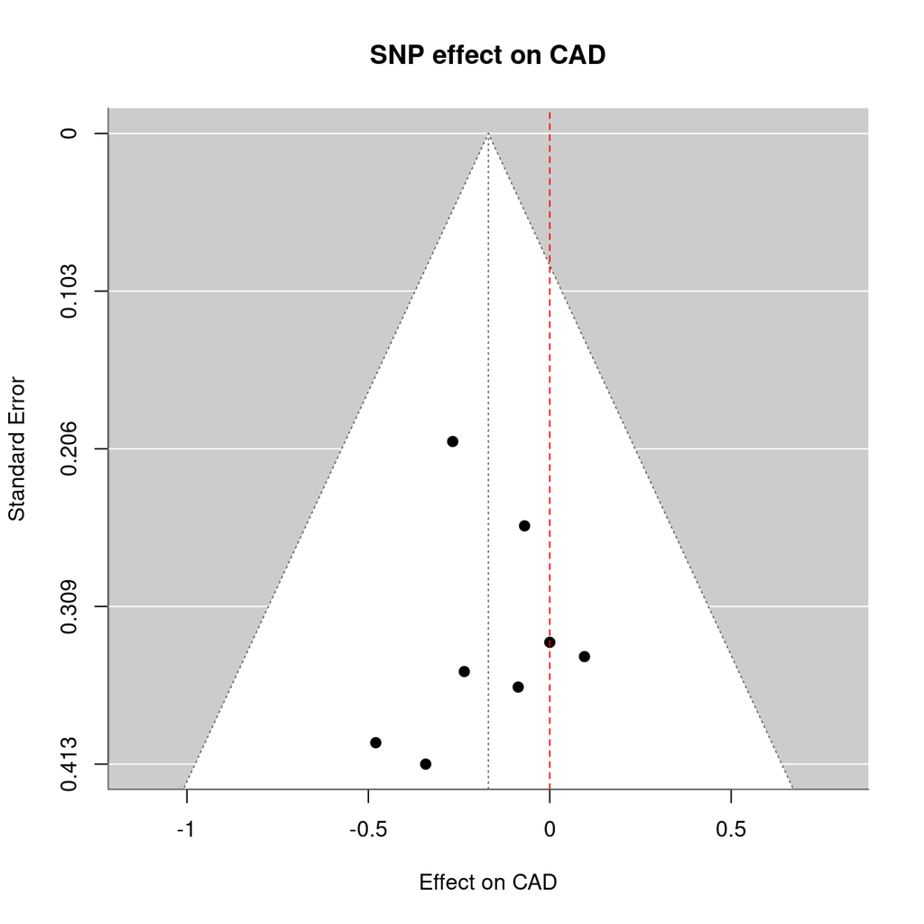

Figure 12.1: Mendelian randomization

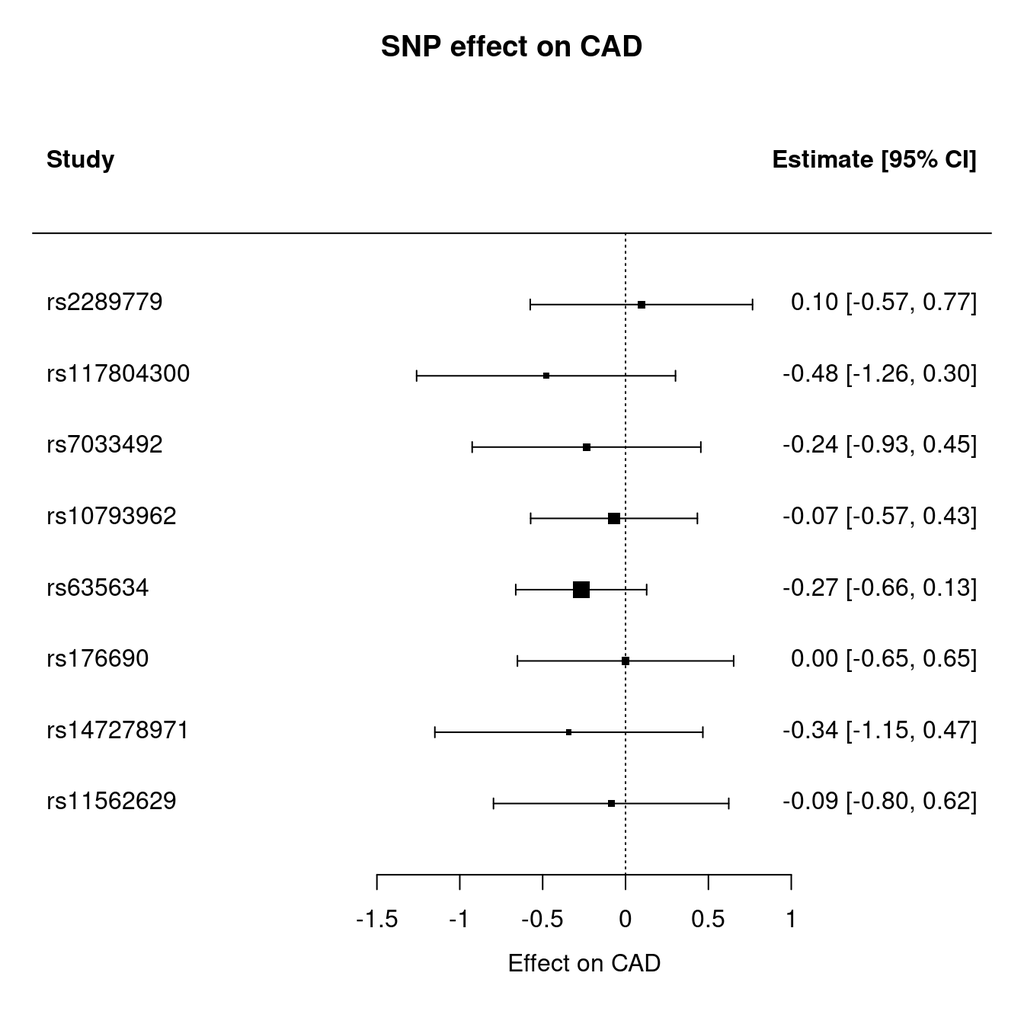

Figure 12.2: Mendelian randomization

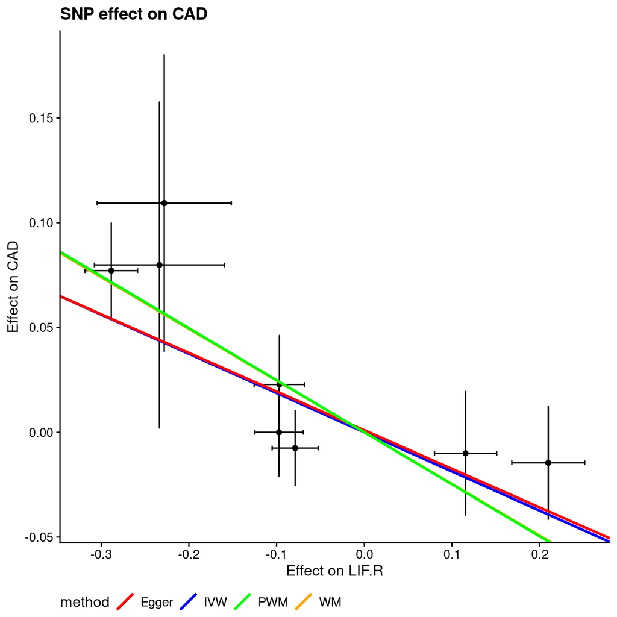

Figure 12.3: Mendelian randomization

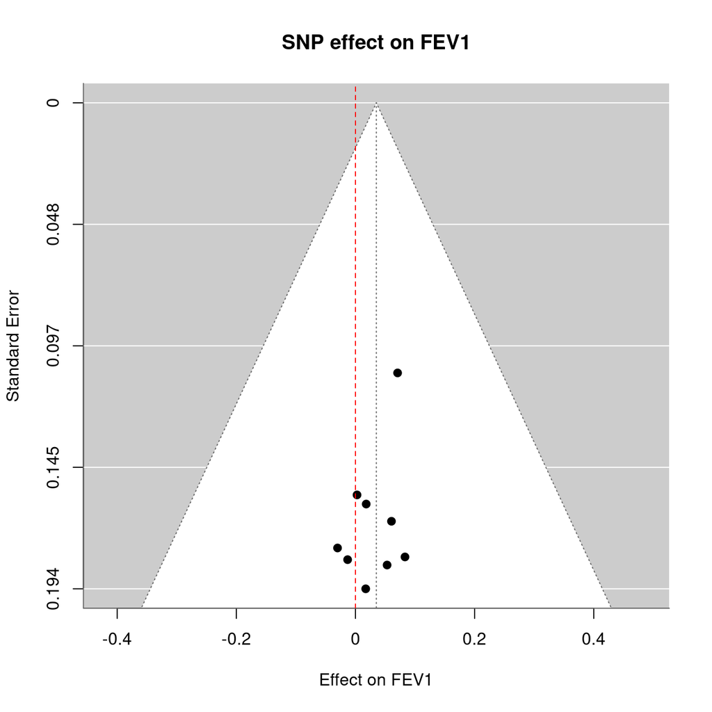

Figure 12.4: Mendelian randomization

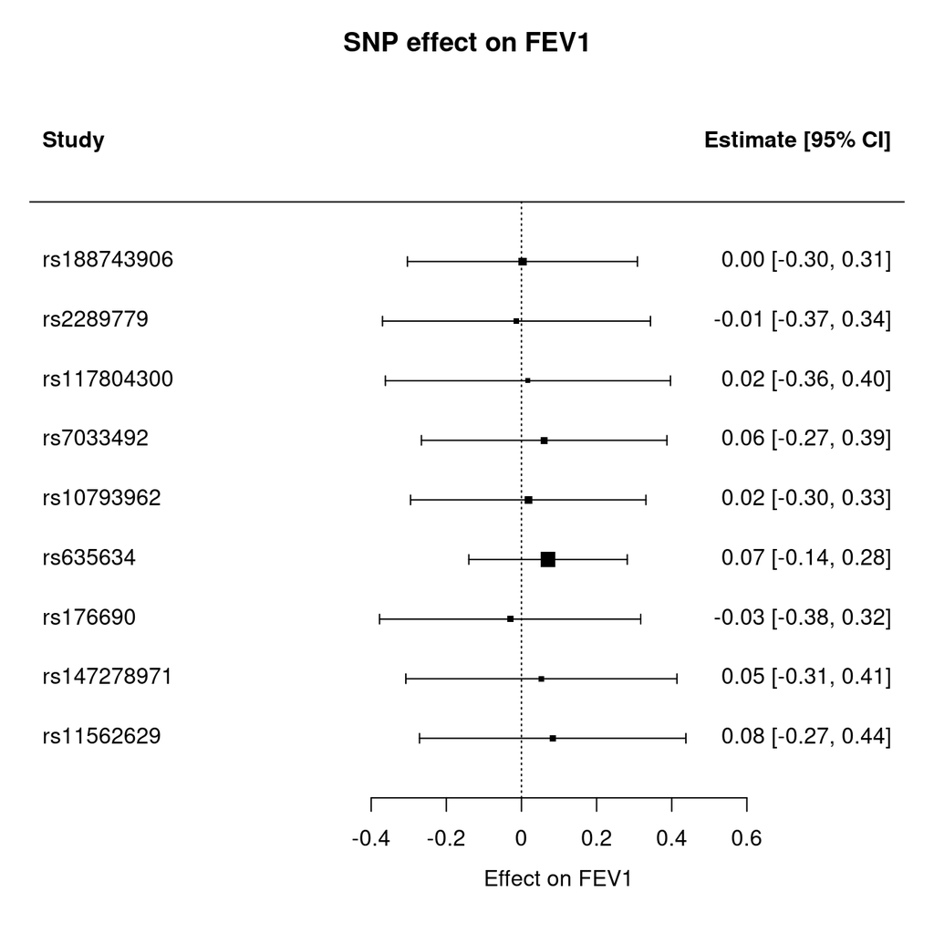

Figure 12.5: Mendelian randomization

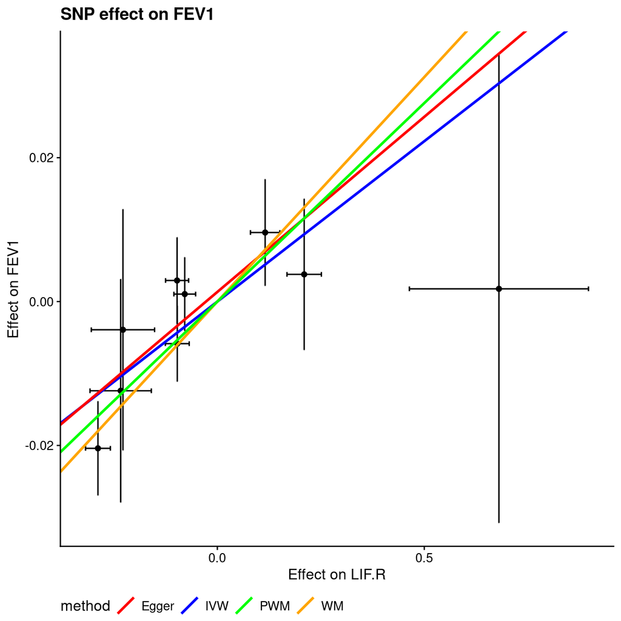

Figure 12.6: Mendelian randomization

Table 12.2: LIFR variant rs635634 and CAD/FEV1

| bIVW | -0.187 | 0.045 |
| --- | --- | --- |
| sebIVW | 0.050 | 0.012 |
| CochQ | 2.116 | 0.482 |
| CochQp | 0.953 | 1.000 |
| bEGGER | -0.184 | 0.049 |
| sebEGGER | 0.060 | 0.015 |
| intEGGER | 0.001 | 0.001 |
| seintEGGER | 0.010 | 0.002 |
| bWM | -0.247 | 0.062 |
| sebWM | 0.048 | 0.012 |
| bPWM | -0.248 | 0.055 |
| sebPWM | 0.042 | 0.013 |
| pIVW | 1.786342e-04 | 3.187050e-04 |
| pEGGER | 2.151003e-03 | 1.125669e-03 |
| pWM | 2.573232e-07 | 7.084748e-08 |
| pPWM | 4.132171e-09 | 2.980983e-05 |

This is close to Ligthart et al.<sup>21</sup> as used one time at workplace which turns to overlap with TwoSampleMR<sup>22</sup>.

## 12.2 Contrast of effect sizes

It would be of interest to contrast their effect sizes in the analysis above as well,

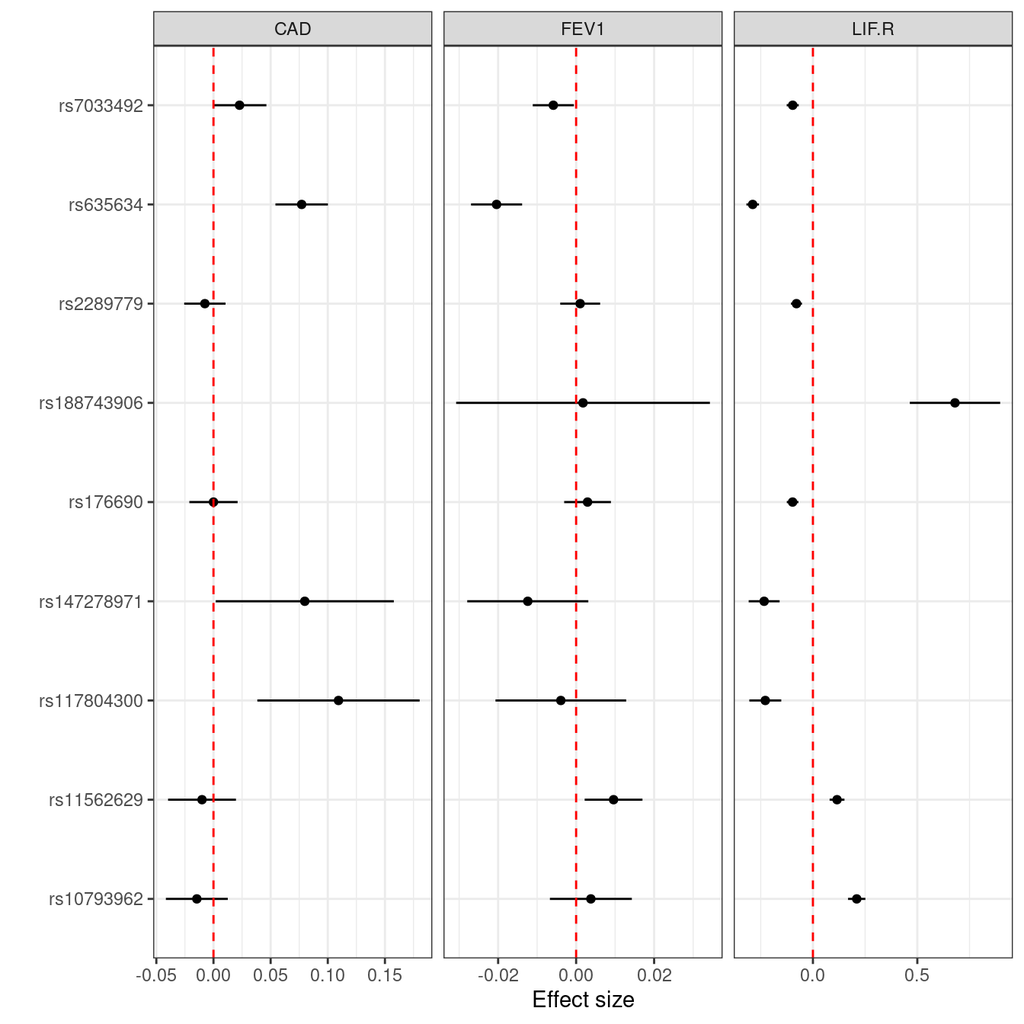

Figure 12.7: Combined forest plots for LIF.R, FEV1 and CAD

```r
mr_names <- names(mrdat)
LIF.R <- cbind(mrdat[grepl("SNP|LIF.R",mr_names)],trait="LIF.R"); names(LIF.R) <- c("SNP","b","se","trait")
FEV1 <- cbind(mrdat[grepl("SNP|FEV1",mr_names)],trait="FEV1"); names(FEV1) <- c("SNP","b","se","trait")
CAD <- cbind(mrdat[grepl("SNP|CAD",mr_names)],trait="CAD"); names(CAD) <- c("SNP","b","se","trait")
mrdat2 <- within(rbind(LIF.R,FEV1,CAD),{y=b})
library(ggplot2)
p <- ggplot2::ggplot(mrdat2,aes(y = SNP, x = y))+
     ggplot2::theme_bw()+
     ggplot2::geom_point()+
     ggplot2::facet_wrap(~ trait, ncol=3, scales="free_x")+
     ggplot2::geom_segment(aes(x = b-1.96*se, xend = b+1.96*se, yend = SNP))+
     ggplot2::geom_vline(lty=2, ggplot2::aes(xintercept=0), colour = 'red')+
     ggplot2::xlab("Effect size")+
     ggplot2::ylab("")
p
```